# Risk Factor Analysis

## Outcome Variable

**Outcome Variable:** swasted

## Predictor Variables

**Intervention Variable:** predexfd6

**Adjustment Set:**

unadjusted

## Stratifying Variables

The analysis was stratified on these variable(s):

- agecat
- studyid
- country

## Data Summary

| agecat | studyid | country | predexfd6 | swasted | n_cell | n |
| --- | --- | --- | --- | --- | --- | --- |
| Birth | CMC-V-BCS-2002 | INDIA | 1 | 0 | 7 | 7 |
| Birth | CMC-V-BCS-2002 | INDIA | 1 | 1 | 0 | 7 |
| Birth | CMC-V-BCS-2002 | INDIA | 0 | 0 | 0 | 7 |
| Birth | CMC-V-BCS-2002 | INDIA | 0 | 1 | 0 | 7 |
| Birth | EE | PAKISTAN | 1 | 0 | 24 | 28 |
| Birth | EE | PAKISTAN | 1 | 1 | 0 | 28 |
| Birth | EE | PAKISTAN | 0 | 0 | 3 | 28 |
| Birth | EE | PAKISTAN | 0 | 1 | 1 | 28 |
| Birth | GMS-Nepal | NEPAL | 1 | 0 | 371 | 522 |
| Birth | GMS-Nepal | NEPAL | 1 | 1 | 19 | 522 |
| Birth | GMS-Nepal | NEPAL | 0 | 0 | 129 | 522 |
| Birth | GMS-Nepal | NEPAL | 0 | 1 | 3 | 522 |
| Birth | IRC | INDIA | 1 | 0 | 0 | 12 |
| Birth | IRC | INDIA | 1 | 1 | 0 | 12 |
| Birth | IRC | INDIA | 0 | 0 | 12 | 12 |
| Birth | IRC | INDIA | 0 | 1 | 0 | 12 |
| Birth | JiVitA-3 | BANGLADESH | 1 | 0 | 8220 | 10744 |
| Birth | JiVitA-3 | BANGLADESH | 1 | 1 | 172 | 10744 |
| Birth | JiVitA-3 | BANGLADESH | 0 | 0 | 2314 | 10744 |
| Birth | JiVitA-3 | BANGLADESH | 0 | 1 | 38 | 10744 |
| Birth | JiVitA-4 | BANGLADESH | 1 | 0 | 1783 | 2224 |
| Birth | JiVitA-4 | BANGLADESH | 1 | 1 | 19 | 2224 |
| Birth | JiVitA-4 | BANGLADESH | 0 | 0 | 412 | 2224 |
| Birth | JiVitA-4 | BANGLADESH | 0 | 1 | 10 | 2224 |
| Birth | Keneba | GAMBIA | 1 | 0 | 411 | 1327 |
| Birth | Keneba | GAMBIA | 1 | 1 | 39 | 1327 |
| Birth | Keneba | GAMBIA | 0 | 0 | 820 | 1327 |
| Birth | Keneba | GAMBIA | 0 | 1 | 57 | 1327 |
| Birth | MAL-ED | BANGLADESH | 1 | 0 | 68 | 194 |
| Birth | MAL-ED | BANGLADESH | 1 | 1 | 0 | 194 |

[output cut: 170 more lines]

The following strata were considered:

- agecat: 24 months, studyid: CMC-V-BCS-2002, country: INDIA
- agecat: 24 months, studyid: EE, country: PAKISTAN
- agecat: 24 months, studyid: GMS-Nepal, country: NEPAL
- agecat: 24 months, studyid: IRC, country: INDIA
- agecat: 24 months, studyid: JiVitA-3, country: BANGLADESH
- agecat: 24 months, studyid: JiVitA-4, country: BANGLADESH
- agecat: 24 months, studyid: Keneba, country: GAMBIA
- agecat: 24 months, studyid: LCNI-5, country: MALAWI
- agecat: 24 months, studyid: MAL-ED, country: BANGLADESH
- agecat: 24 months, studyid: MAL-ED, country: BRAZIL
- agecat: 24 months, studyid: MAL-ED, country: INDIA
- agecat: 24 months, studyid: MAL-ED, country: NEPAL
- agecat: 24 months, studyid: MAL-ED, country: PERU
- agecat: 24 months, studyid: MAL-ED, country: SOUTH AFRICA
- agecat: 24 months, studyid: MAL-ED, country: TANZANIA, UNITED REPUBLIC OF
- agecat: 24 months, studyid: PROVIDE, country: BANGLADESH
- agecat: 6 months, studyid: CMC-V-BCS-2002, country: INDIA
- agecat: 6 months, studyid: EE, country: PAKISTAN
- agecat: 6 months, studyid: GMS-Nepal, country: NEPAL
- agecat: 6 months, studyid: IRC, country: INDIA
- agecat: 6 months, studyid: JiVitA-3, country: BANGLADESH
- agecat: 6 months, studyid: JiVitA-4, country: BANGLADESH
- agecat: 6 months, studyid: Keneba, country: GAMBIA
- agecat: 6 months, studyid: LCNI-5, country: MALAWI
- agecat: 6 months, studyid: MAL-ED, country: BANGLADESH
- agecat: 6 months, studyid: MAL-ED, country: BRAZIL
- agecat: 6 months, studyid: MAL-ED, country: INDIA
- agecat: 6 months, studyid: MAL-ED, country: NEPAL
- agecat: 6 months, studyid: MAL-ED, country: PERU
- agecat: 6 months, studyid: MAL-ED, country: SOUTH AFRICA
- agecat: 6 months, studyid: MAL-ED, country: TANZANIA, UNITED REPUBLIC OF
- agecat: 6 months, studyid: PROVIDE, country: BANGLADESH
- agecat: 6 months, studyid: SAS-CompFeed, country: INDIA
- agecat: 6 months, studyid: SAS-FoodSuppl, country: INDIA
- agecat: Birth, studyid: CMC-V-BCS-2002, country: INDIA
- agecat: Birth, studyid: EE, country: PAKISTAN
- agecat: Birth, studyid: GMS-Nepal, country: NEPAL
- agecat: Birth, studyid: IRC, country: INDIA
- agecat: Birth, studyid: JiVitA-3, country: BANGLADESH
- agecat: Birth, studyid: JiVitA-4, country: BANGLADESH
- agecat: Birth, studyid: Keneba, country: GAMBIA
- agecat: Birth, studyid: MAL-ED, country: BANGLADESH
- agecat: Birth, studyid: MAL-ED, country: BRAZIL
- agecat: Birth, studyid: MAL-ED, country: INDIA
- agecat: Birth, studyid: MAL-ED, country: NEPAL
- agecat: Birth, studyid: MAL-ED, country: PERU
- agecat: Birth, studyid: MAL-ED, country: SOUTH AFRICA
- agecat: Birth, studyid: MAL-ED, country: TANZANIA, UNITED REPUBLIC OF
- agecat: Birth, studyid: PROVIDE, country: BANGLADESH
- agecat: Birth, studyid: SAS-CompFeed, country: INDIA

### Dropped Strata

Some strata were dropped due to rare outcomes:

- agecat: Birth, studyid: CMC-V-BCS-2002, country: INDIA
- agecat: Birth, studyid: EE, country: PAKISTAN
- agecat: Birth, studyid: GMS-Nepal, country: NEPAL
- agecat: Birth, studyid: IRC, country: INDIA
- agecat: Birth, studyid: MAL-ED, country: BANGLADESH
- agecat: Birth, studyid: MAL-ED, country: BRAZIL
- agecat: Birth, studyid: MAL-ED, country: INDIA
- agecat: Birth, studyid: MAL-ED, country: NEPAL
- agecat: Birth, studyid: MAL-ED, country: PERU
- agecat: Birth, studyid: MAL-ED, country: SOUTH AFRICA
- agecat: Birth, studyid: MAL-ED, country: TANZANIA, UNITED REPUBLIC OF
- agecat: Birth, studyid: PROVIDE, country: BANGLADESH
- agecat: Birth, studyid: SAS-CompFeed, country: INDIA
- agecat: 6 months, studyid: CMC-V-BCS-2002, country: INDIA
- agecat: 6 months, studyid: EE, country: PAKISTAN
- agecat: 6 months, studyid: GMS-Nepal, country: NEPAL
- agecat: 6 months, studyid: IRC, country: INDIA
- agecat: 6 months, studyid: LCNI-5, country: MALAWI
- agecat: 6 months, studyid: MAL-ED, country: BANGLADESH
- agecat: 6 months, studyid: MAL-ED, country: BRAZIL
- agecat: 6 months, studyid: MAL-ED, country: INDIA
- agecat: 6 months, studyid: MAL-ED, country: NEPAL
- agecat: 6 months, studyid: MAL-ED, country: PERU
- agecat: 6 months, studyid: MAL-ED, country: SOUTH AFRICA
- agecat: 6 months, studyid: MAL-ED, country: TANZANIA, UNITED REPUBLIC OF
- agecat: 6 months, studyid: PROVIDE, country: BANGLADESH
- agecat: 6 months, studyid: SAS-CompFeed, country: INDIA
- agecat: 6 months, studyid: SAS-FoodSuppl, country: INDIA
- agecat: 24 months, studyid: CMC-V-BCS-2002, country: INDIA
- agecat: 24 months, studyid: EE, country: PAKISTAN
- agecat: 24 months, studyid: IRC, country: INDIA
- agecat: 24 months, studyid: LCNI-5, country: MALAWI
- agecat: 24 months, studyid: MAL-ED, country: BANGLADESH
- agecat: 24 months, studyid: MAL-ED, country: BRAZIL
- agecat: 24 months, studyid: MAL-ED, country: INDIA
- agecat: 24 months, studyid: MAL-ED, country: NEPAL
- agecat: 24 months, studyid: MAL-ED, country: PERU
- agecat: 24 months, studyid: MAL-ED, country: SOUTH AFRICA
- agecat: 24 months, studyid: MAL-ED, country: TANZANIA, UNITED REPUBLIC OF
- agecat: 24 months, studyid: PROVIDE, country: BANGLADESH

## Methods Detail

We’re interested in the causal parameters $E[Y_a]$ for all values of $a \in \mathcal{A}$. These parameters represent the mean outcome if, possibly contrary to fact, we intervened to set all units to have $A=a$. Under the randomization and positivity assumptions, these are identified by the statistical parameters $\psi_a=E_W[E_{Y|A,W}(Y|A=a,W)]$. In addition, we’re interested in the mean of $Y$, $E[Y]$ under no intervention (the observed mean). We will estimate these parameters by using SuperLearner to fit the relevant likelihood factors – $E_{Y|A,W}(Y|A=a,W)$ and $p(A=a|W)$, and then updating our likelihood fit using a joint TMLE.

For unadjusted analyses ($W=\{\}$), initial likelihoods were estimated using Lrnr_glm to estimate the simple $E(Y|A)$ and Lrnr_mean to estimate $p(A)$. For adjusted analyses, a small library containing Lrnr_glmnet, Lrnr_xgboost, and Lrnr_mean was used.

Having estimated these parameters, we will then use the delta method to estimate relative risks and attributable risks relative to a prespecified baseline level of $A$.

# Results Detail

## Results Plots

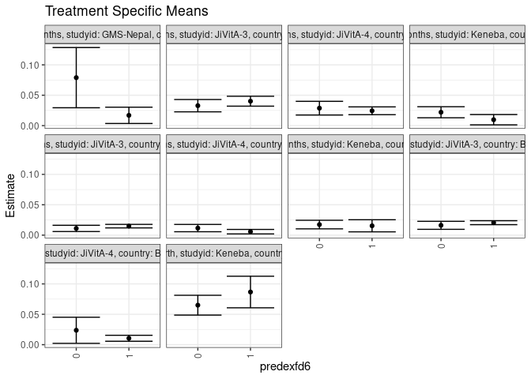

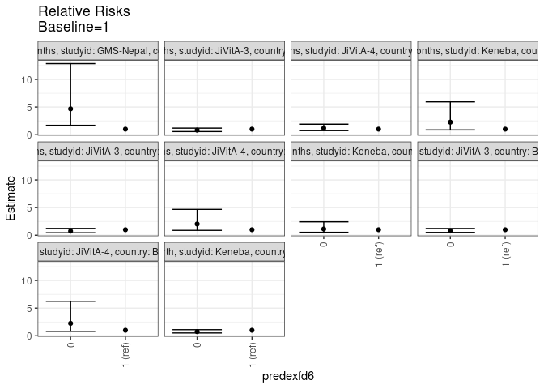

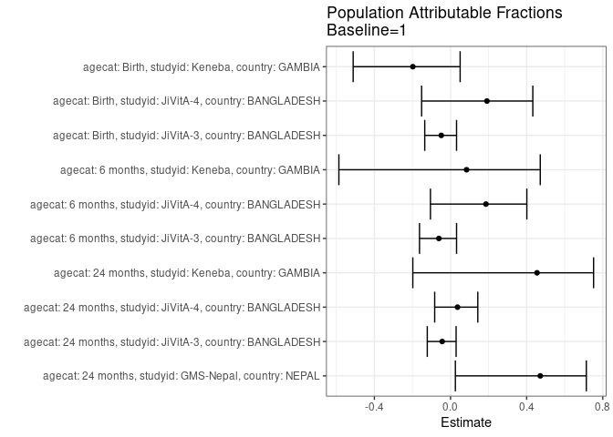

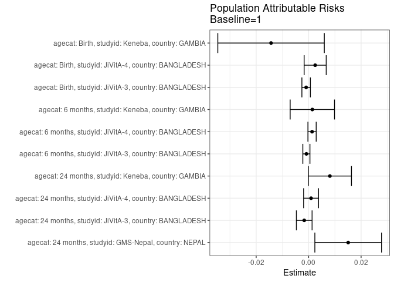

## Results Table

### Parameter: TSM

| agecat | studyid | country | intervention_level | baseline_level | estimate | ci_lower | ci_upper |
| --- | --- | --- | --- | --- | --- | --- | --- |
| Birth | JiVitA-3 | BANGLADESH | 1 | NA | 0.0204957 | 0.0172481 | 0.0237433 |
| Birth | JiVitA-3 | BANGLADESH | 0 | NA | 0.0161565 | 0.0095646 | 0.0227484 |
| Birth | JiVitA-4 | BANGLADESH | 1 | NA | 0.0105438 | 0.0056293 | 0.0154584 |
| Birth | JiVitA-4 | BANGLADESH | 0 | NA | 0.0236967 | 0.0022219 | 0.0451714 |
| Birth | Keneba | GAMBIA | 1 | NA | 0.0866667 | 0.0606623 | 0.1126710 |
| Birth | Keneba | GAMBIA | 0 | NA | 0.0649943 | 0.0486729 | 0.0813157 |
| 6 months | JiVitA-3 | BANGLADESH | 1 | NA | 0.0148197 | 0.0119197 | 0.0177197 |
| 6 months | JiVitA-3 | BANGLADESH | 0 | NA | 0.0110767 | 0.0059602 | 0.0161931 |
| 6 months | JiVitA-4 | BANGLADESH | 1 | NA | 0.0057109 | 0.0020227 | 0.0093990 |
| 6 months | JiVitA-4 | BANGLADESH | 0 | NA | 0.0116034 | 0.0055832 | 0.0176236 |
| 6 months | Keneba | GAMBIA | 1 | NA | 0.0153584 | 0.0053992 | 0.0253176 |
| 6 months | Keneba | GAMBIA | 0 | NA | 0.0173979 | 0.0103480 | 0.0244478 |
| 24 months | GMS-Nepal | NEPAL | 1 | NA | 0.0169014 | 0.0034782 | 0.0303246 |
| 24 months | GMS-Nepal | NEPAL | 0 | NA | 0.0789474 | 0.0293943 | 0.1285004 |
| 24 months | JiVitA-3 | BANGLADESH | 1 | NA | 0.0401637 | 0.0320064 | 0.0483211 |
| 24 months | JiVitA-3 | BANGLADESH | 0 | NA | 0.0328152 | 0.0226906 | 0.0429398 |
| 24 months | JiVitA-4 | BANGLADESH | 1 | NA | 0.0244051 | 0.0179842 | 0.0308260 |
| 24 months | JiVitA-4 | BANGLADESH | 0 | NA | 0.0286976 | 0.0174361 | 0.0399591 |
| 24 months | Keneba | GAMBIA | 1 | NA | 0.0097276 | 0.0012399 | 0.0182153 |
| 24 months | Keneba | GAMBIA | 0 | NA | 0.0220000 | 0.0129056 | 0.0310944 |

### Parameter: E(Y)

| agecat | studyid | country | intervention_level | baseline_level | estimate | ci_lower | ci_upper |
| --- | --- | --- | --- | --- | --- | --- | --- |
| Birth | JiVitA-3 | BANGLADESH | NA | NA | 0.0195458 | 0.0166489 | 0.0224427 |
| Birth | JiVitA-4 | BANGLADESH | NA | NA | 0.0130396 | 0.0073461 | 0.0187330 |
| Birth | Keneba | GAMBIA | NA | NA | 0.0723436 | 0.0584002 | 0.0862871 |
| 6 months | JiVitA-3 | BANGLADESH | NA | NA | 0.0139648 | 0.0114567 | 0.0164729 |
| 6 months | JiVitA-4 | BANGLADESH | NA | NA | 0.0070175 | 0.0038738 | 0.0101612 |
| 6 months | Keneba | GAMBIA | NA | NA | 0.0167715 | 0.0110080 | 0.0225350 |
| 24 months | GMS-Nepal | NEPAL | NA | NA | 0.0319829 | 0.0160416 | 0.0479243 |
| 24 months | JiVitA-3 | BANGLADESH | NA | NA | 0.0384843 | 0.0318086 | 0.0451600 |
| 24 months | JiVitA-4 | BANGLADESH | NA | NA | 0.0253346 | 0.0198022 | 0.0308670 |
| 24 months | Keneba | GAMBIA | NA | NA | 0.0178336 | 0.0111649 | 0.0245022 |

### Parameter: RR

| agecat | studyid | country | intervention_level | baseline_level | estimate | ci_lower | ci_upper |
| --- | --- | --- | --- | --- | --- | --- | --- |
| Birth | JiVitA-3 | BANGLADESH | 1 | 1 | 1.0000000 | 1.0000000 | 1.000000 |
| Birth | JiVitA-3 | BANGLADESH | 0 | 1 | 0.7882851 | 0.5075555 | 1.224287 |
| Birth | JiVitA-4 | BANGLADESH | 1 | 1 | 1.0000000 | 1.0000000 | 1.000000 |
| Birth | JiVitA-4 | BANGLADESH | 0 | 1 | 2.2474433 | 0.8096472 | 6.238521 |
| Birth | Keneba | GAMBIA | 1 | 1 | 1.0000000 | 1.0000000 | 1.000000 |
| Birth | Keneba | GAMBIA | 0 | 1 | 0.7499342 | 0.5071041 | 1.109045 |
| 6 months | JiVitA-3 | BANGLADESH | 1 | 1 | 1.0000000 | 1.0000000 | 1.000000 |
| 6 months | JiVitA-3 | BANGLADESH | 0 | 1 | 0.7474288 | 0.4509941 | 1.238708 |
| 6 months | JiVitA-4 | BANGLADESH | 1 | 1 | 1.0000000 | 1.0000000 | 1.000000 |
| 6 months | JiVitA-4 | BANGLADESH | 0 | 1 | 2.0318121 | 0.8808884 | 4.686474 |
| 6 months | Keneba | GAMBIA | 1 | 1 | 1.0000000 | 1.0000000 | 1.000000 |
| 6 months | Keneba | GAMBIA | 0 | 1 | 1.1327954 | 0.5273112 | 2.433526 |
| 24 months | GMS-Nepal | NEPAL | 1 | 1 | 1.0000000 | 1.0000000 | 1.000000 |
| 24 months | GMS-Nepal | NEPAL | 0 | 1 | 4.6710526 | 1.6973880 | 12.854299 |
| 24 months | JiVitA-3 | BANGLADESH | 1 | 1 | 1.0000000 | 1.0000000 | 1.000000 |
| 24 months | JiVitA-3 | BANGLADESH | 0 | 1 | 0.8170357 | 0.5633987 | 1.184858 |
| 24 months | JiVitA-4 | BANGLADESH | 1 | 1 | 1.0000000 | 1.0000000 | 1.000000 |
| 24 months | JiVitA-4 | BANGLADESH | 0 | 1 | 1.1758830 | 0.7291736 | 1.896257 |
| 24 months | Keneba | GAMBIA | 1 | 1 | 1.0000000 | 1.0000000 | 1.000000 |
| 24 months | Keneba | GAMBIA | 0 | 1 | 2.2616000 | 0.8611947 | 5.939231 |

### Parameter: PAR

| agecat | studyid | country | intervention_level | baseline_level | estimate | ci_lower | ci_upper |
| --- | --- | --- | --- | --- | --- | --- | --- |
| Birth | JiVitA-3 | BANGLADESH | 1 | NA | -0.0009499 | -0.0025684 | 0.0006686 |
| Birth | JiVitA-4 | BANGLADESH | 1 | NA | 0.0024957 | -0.0017114 | 0.0067028 |
| Birth | Keneba | GAMBIA | 1 | NA | -0.0143230 | -0.0346212 | 0.0059751 |
| 6 months | JiVitA-3 | BANGLADESH | 1 | NA | -0.0008549 | -0.0022103 | 0.0005005 |
| 6 months | JiVitA-4 | BANGLADESH | 1 | NA | 0.0013067 | -0.0002711 | 0.0028845 |
| 6 months | Keneba | GAMBIA | 1 | NA | 0.0014131 | -0.0070414 | 0.0098676 |
| 24 months | GMS-Nepal | NEPAL | 1 | NA | 0.0150815 | 0.0023717 | 0.0277913 |
| 24 months | JiVitA-3 | BANGLADESH | 1 | NA | -0.0016794 | -0.0046737 | 0.0013148 |
| 24 months | JiVitA-4 | BANGLADESH | 1 | NA | 0.0009295 | -0.0019098 | 0.0037687 |
| 24 months | Keneba | GAMBIA | 1 | NA | 0.0081059 | -0.0001158 | 0.0163277 |

### Parameter: PAF

| agecat | studyid | country | intervention_level | baseline_level | estimate | ci_lower | ci_upper |
| --- | --- | --- | --- | --- | --- | --- | --- |
| Birth | JiVitA-3 | BANGLADESH | 1 | NA | -0.0485996 | -0.1354855 | 0.0316379 |
| Birth | JiVitA-4 | BANGLADESH | 1 | NA | 0.1913965 | -0.1518655 | 0.4323646 |
| Birth | Keneba | GAMBIA | 1 | NA | -0.1979861 | -0.5114710 | 0.0504808 |
| 6 months | JiVitA-3 | BANGLADESH | 1 | NA | -0.0612174 | -0.1630362 | 0.0316876 |
| 6 months | JiVitA-4 | BANGLADESH | 1 | NA | 0.1862038 | -0.1055211 | 0.4009483 |
| 6 months | Keneba | GAMBIA | 1 | NA | 0.0842577 | -0.5865784 | 0.4714513 |
| 24 months | GMS-Nepal | NEPAL | 1 | NA | 0.4715493 | 0.0254393 | 0.7134502 |
| 24 months | JiVitA-3 | BANGLADESH | 1 | NA | -0.0436389 | -0.1221301 | 0.0293619 |
| 24 months | JiVitA-4 | BANGLADESH | 1 | NA | 0.0366883 | -0.0832125 | 0.1433172 |
| 24 months | Keneba | GAMBIA | 1 | NA | 0.4545324 | -0.1981385 | 0.7516690 |